# Exercise 4

```python
import pandas as pd
## Gestión de imagenes
import cv2
## Gestión de datos
import matplotlib.pyplot as plt
import seaborn as sns
```

## Importar datos con Pandas

```python
daily_prices = pd.read_csv('data/stocks_daily_prices.csv', parse_dates=['Date'])
daily_returns = pd.read_csv('data/stocks_daily_returns.csv', parse_dates=['Date'])

print(daily_prices)
print(daily_returns)
```

```
           Date        AAPL         JPM          PG        UAL
0    2008-01-02    5.949703   29.448614   47.058838  29.915234
1    2008-01-03    5.952452   29.246094   47.058838  29.690800
2    2008-01-04    5.498071   28.582682   46.870098  31.000002
3    2008-01-07    5.424478   28.868999   47.175980  29.180000
4    2008-01-08    5.229351   27.723747   47.299629  24.389999
...         ...         ...         ...         ...        ...
3637 2022-06-13  131.880005  115.989998  138.149994  37.020000
3638 2022-06-14  132.759995  114.059998  133.839996  36.990002
3639 2022-06-15  135.429993  115.410004  132.509995  37.889999
3640 2022-06-16  130.059998  113.430000  133.320007  34.779999
3641 2022-06-17  131.559998  113.029999  132.360001  36.279999

[3642 rows x 5 columns]
           Date      AAPL       JPM        PG        UAL
0    2008-01-02  0.000000  0.000000  0.000000   0.000000
1    2008-01-03  0.046203 -0.687708  0.000000  -0.750233
2    2008-01-04 -7.633517 -2.268378 -0.401072   4.409454
3    2008-01-07 -1.338518  1.001718  0.652615  -5.870973
4    2008-01-08 -3.597157 -3.967066  0.262103 -16.415356
...         ...       ...       ...       ...        ...
3637 2022-06-13 -3.828484 -2.977838 -2.677001 -10.058308
3638 2022-06-14  0.667265 -1.663937 -3.119796  -0.081034
3639 2022-06-15  2.011147  1.183593 -0.993725   2.433084
3640 2022-06-16 -3.965145 -1.715625  0.611284  -8.207972
3641 2022-06-17  1.153314 -0.352642 -0.720077   4.312824

[3642 rows x 5 columns]
```

## Diagramas de líneas que muestran los precios diarios de las 4 acciones en una sola cifra.

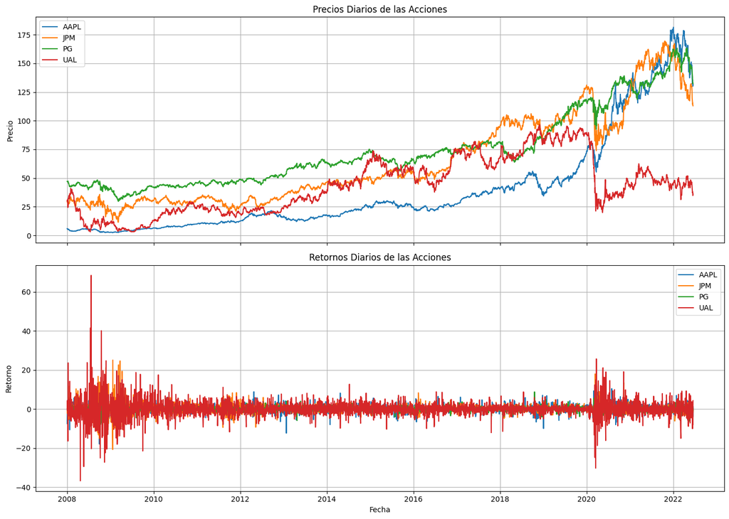

```python
# Configuración de la figura
fig, axes = plt.subplots(2, 1, figsize=(14, 10), sharex=True)

# Graficar precios diarios
for column in ['AAPL', 'JPM', 'PG', 'UAL']:
    axes[0].plot(daily_prices['Date'], daily_prices[column], label=column)

axes[0].set_title('Precios Diarios de las Acciones')
axes[0].set_ylabel('Precio')
axes[0].legend()
axes[0].grid(True)

# Graficar retornos diarios
for column in ['AAPL', 'JPM', 'PG', 'UAL']:
    axes[1].plot(daily_returns['Date'], daily_returns[column], label=column)

axes[1].set_title('Retornos Diarios de las Acciones')
axes[1].set_ylabel('Retorno')
axes[1].set_xlabel('Fecha')
axes[1].legend()
axes[1].grid(True)

# Mostrar el gráfico
plt.tight_layout()
plt.show()
```

## 4 precios diarios de acciones en varias suplots

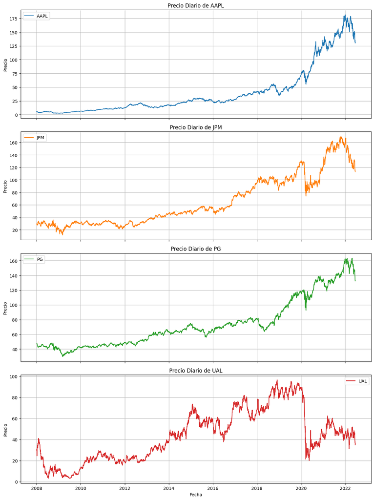

```python
# Configuración de la figura y subplots
fig, axes = plt.subplots(4, 1, figsize=(12, 16), sharex=True)

# Lista de nombres de las acciones
stocks = ['AAPL', 'JPM', 'PG', 'UAL']

# Crear un subplot para cada acción
for i, stock in enumerate(stocks):
    axes[i].plot(daily_prices['Date'], daily_prices[stock], label=stock, color=f"C{i}")
    axes[i].set_title(f"Precio Diario de {stock}")
    axes[i].set_ylabel('Precio')
    axes[i].legend()
    axes[i].grid(True)

# Etiqueta común para el eje X
axes[-1].set_xlabel('Fecha')

# Ajustar espaciado
plt.tight_layout()
plt.show()
```

## 4 plots en subplots una al lado de la otra (todas las figuras en una fila)

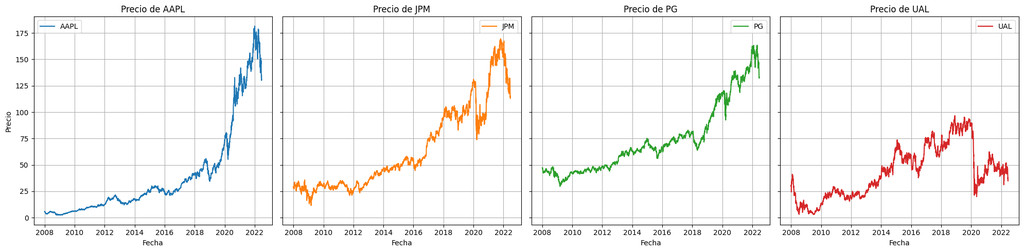

```python
# Configuración de la figura y subplots
fig, axes = plt.subplots(1, 4, figsize=(20, 5), sharey=True)

# Lista de nombres de las acciones
stocks = ['AAPL', 'JPM', 'PG', 'UAL']

# Crear un subplot horizontal para cada acción
for i, stock in enumerate(stocks):
    axes[i].plot(daily_prices['Date'], daily_prices[stock], label=stock, color=f"C{i}")
    axes[i].set_title(f"Precio de {stock}")
    axes[i].set_xlabel('Fecha')
    axes[i].legend()
    axes[i].grid(True)

# Etiqueta común para el eje Y
axes[0].set_ylabel('Precio')

# Ajustar espaciado
plt.tight_layout()
plt.show()
```

## Diagrama de dispersión entre los rendimientos diarios de Apple (AAPL) y JP Morgan (JPM)

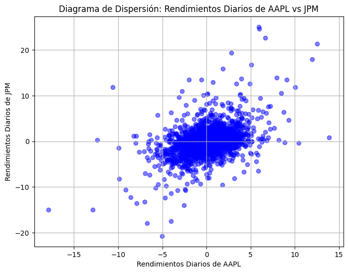

```python
# Crear el diagrama de dispersión
plt.figure(figsize=(8, 6))
plt.scatter(daily_returns['AAPL'], daily_returns['JPM'], alpha=0.5, color='blue')

# Configurar títulos y etiquetas
plt.title('Diagrama de Dispersión: Rendimientos Diarios de AAPL vs JPM')
plt.xlabel('Rendimientos Diarios de AAPL')
plt.ylabel('Rendimientos Diarios de JPM')
plt.grid(True)

# Mostrar el gráfico
plt.show()
```

## Diagrama de dispersión similar entre los rendimientos diarios de Apple y JP Morgan con Seaborn

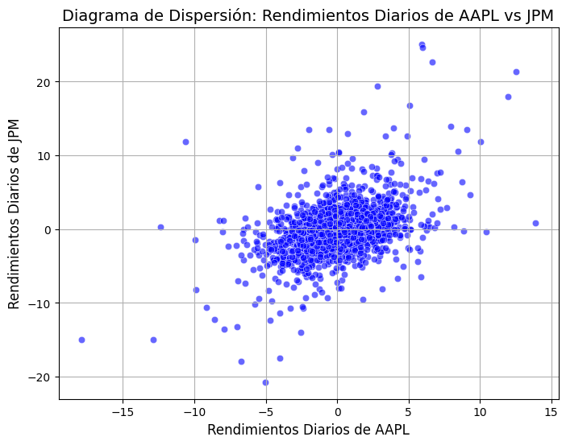

```python
# Crear el diagrama de dispersión con Seaborn
plt.figure(figsize=(8, 6))
sns.scatterplot(
    x=daily_returns['AAPL'],
    y=daily_returns['JPM'],
    alpha=0.6,
    color='blue'
)

# Configurar títulos y etiquetas
plt.title('Diagrama de Dispersión: Rendimientos Diarios de AAPL vs JPM', fontsize=14)
plt.xlabel('Rendimientos Diarios de AAPL', fontsize=12)
plt.ylabel('Rendimientos Diarios de JPM', fontsize=12)
plt.grid(True)

# Mostrar el gráfico
plt.show()
```

## Asignar el 70% sobre AAPL y el resto entre las otras 3 acciones. Gráfico circular que muestre estas asignaciónes utilizando explode

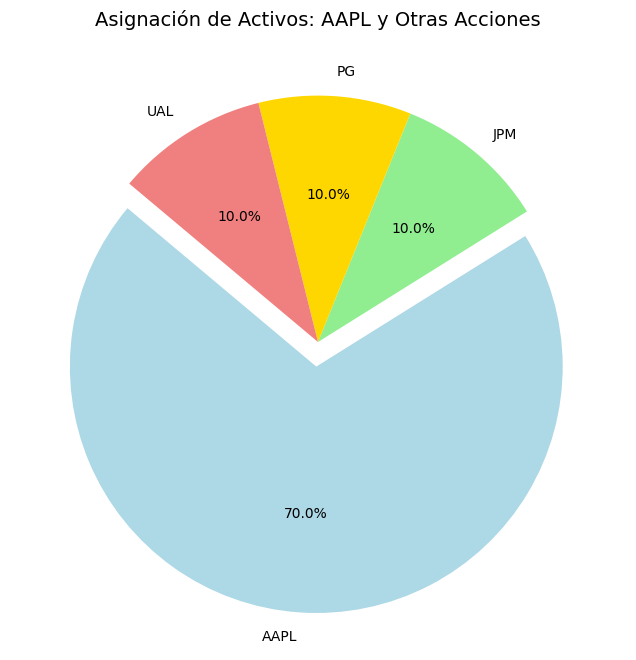

```python
# Datos de la asignación de activos
labels = ['AAPL', 'JPM', 'PG', 'UAL']
sizes = [70, 10, 10, 10]  # 70% para AAPL y 10% cada uno para el resto
explode = (0.1, 0, 0, 0)  # Separación para AAPL

# Crear el gráfico circular
plt.figure(figsize=(8, 8))
plt.pie(
    sizes,
    labels=labels,
    explode=explode,
    autopct='%1.1f%%',
    startangle=140,
    colors=['lightblue', 'lightgreen', 'gold', 'lightcoral']
)

# Configurar título
plt.title('Asignación de Activos: AAPL y Otras Acciones', fontsize=14)

# Mostrar el gráfico
plt.show()
```